# Prospective TDI Incubator Outline

Craig McGowan

February 15, 2019

| location | 1 wk ahead | 2 wk ahead | 3 wk ahead | 4 wk ahead |
| --- | --- | --- | --- | --- |
| US National | 0.32 | 0.37 | 0.48 | 0.49 |
| HHS Region 3 | 0.33 | 0.45 | 0.54 | 0.59 |
| Pennsylvania | 0.19 | 0.54 | 0.59 | 0.59 |
| Virginia | 0.39 | 0.51 | 0.61 | 0.65 |

Geom. mean prob assigned to observed outcome

| location | 1 wk ahead | 2 wk ahead | 3 wk ahead | 4 wk ahead |
| --- | --- | --- | --- | --- |
| US National | 0.76 | 0.57 | 0.47 | 0.44 |
| HHS Region 3 | 0.75 | 0.5 | 0.45 | 0.41 |
| Pennsylvania | 0.77 | 0.46 | 0.44 | 0.43 |
| Virginia | 0.5 | 0.39 | 0.3 | 0.27 |

### Week ahead plots

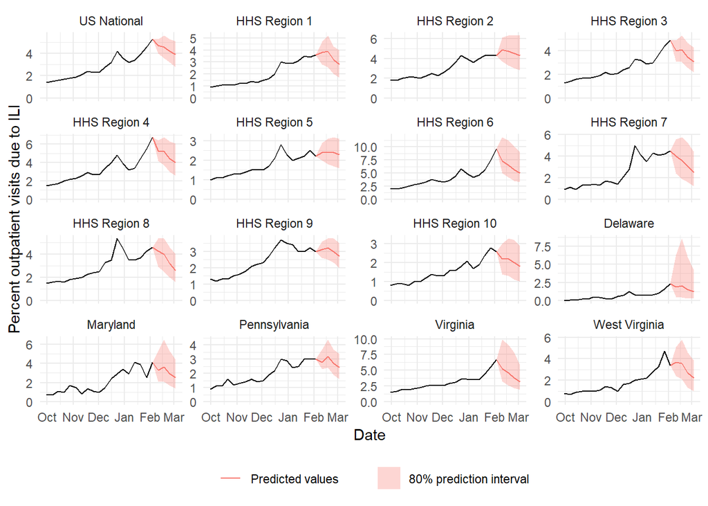

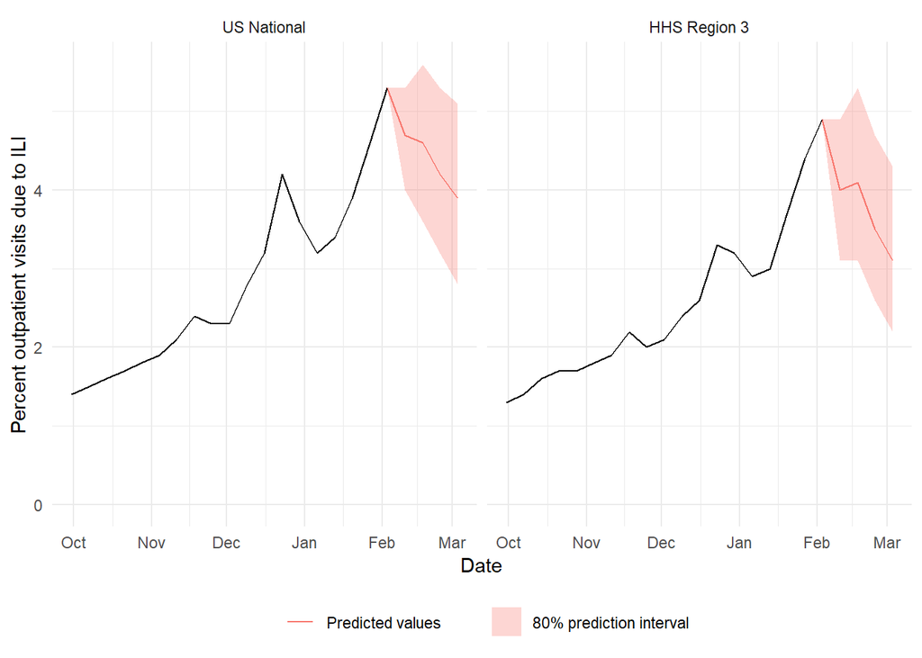

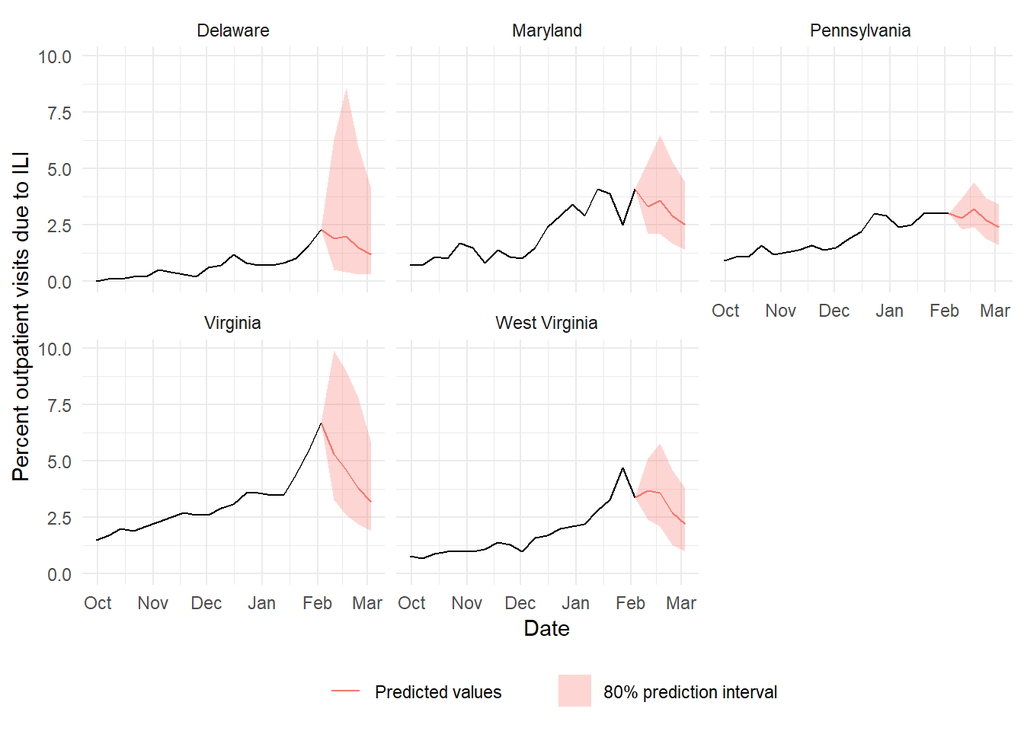

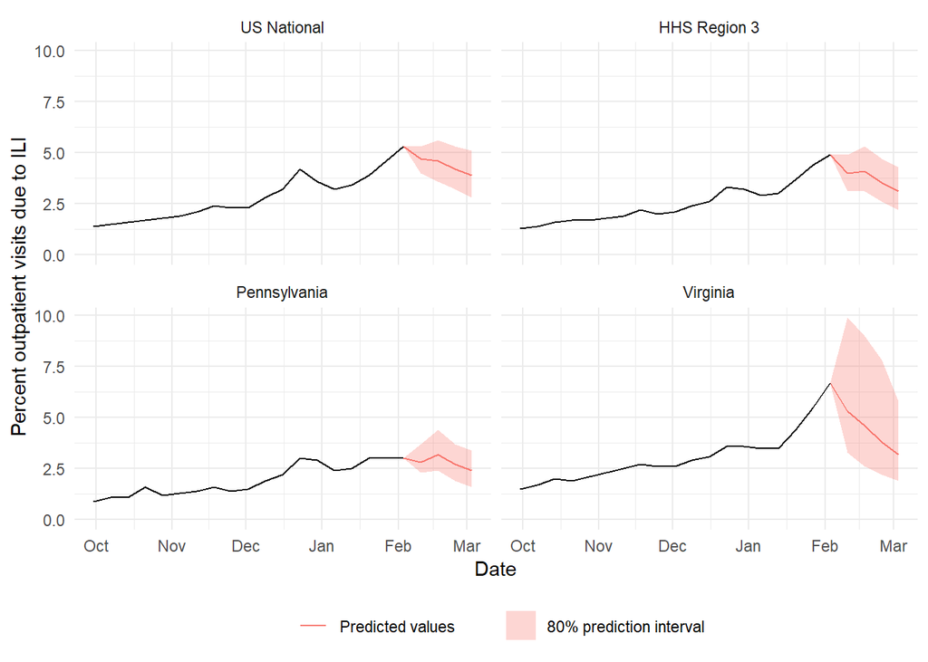

## Outline

### Intro

All had flu, terrible, no good, very bad

### Technical nature

Challenge not size of data, but combining data from multiple sources storing dates differently. Computational effort to fix weekly training forecasts across multiple seasons.

### Takeaways

#### Technical

Accuracy measures - compare MAE of forecasts at different resolutions?

#### Fun facts

Look at forecasts for coming weeks - anything there?

Comparison between states - you live in Maryland but sis in PA, maybe don’t visit

In states in Region 3 - emphasize how using finer resolution forecasts provide different information than national ones (hopefully!) Illustrate with plots of ILI trends across states - maybe overlay different forecasts to show how state one tracks better - but don’t want to undercut own work

### Accomplish at TDI

Finish building out state forecasts and create interactive web application so users (individuals, regional health care providers, media, etc) can explore forecasts at different resolutions, including measures of accuracy.

### Week 40

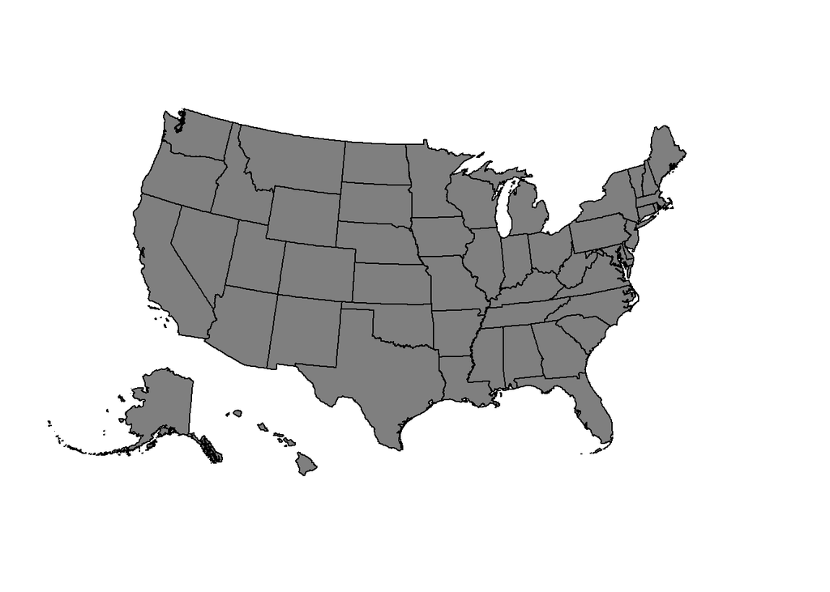

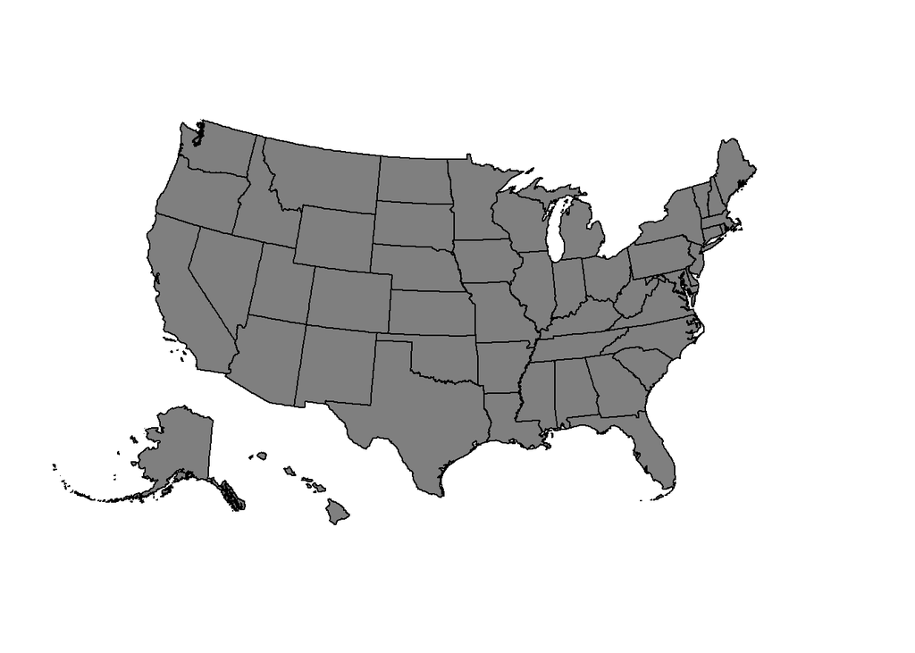

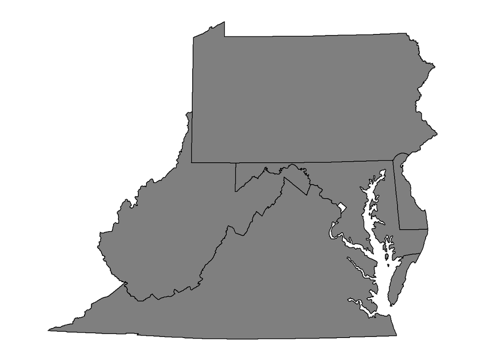

### Week 41

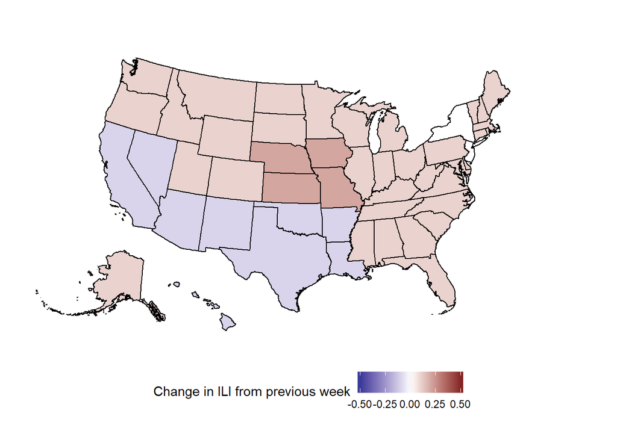

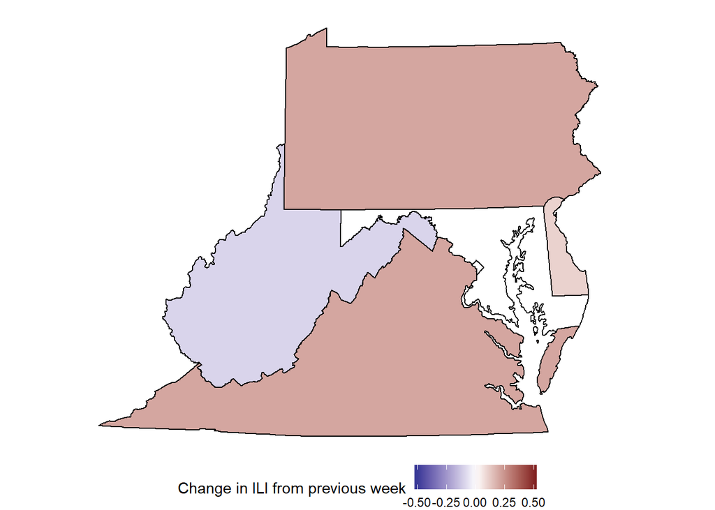

### Week 42

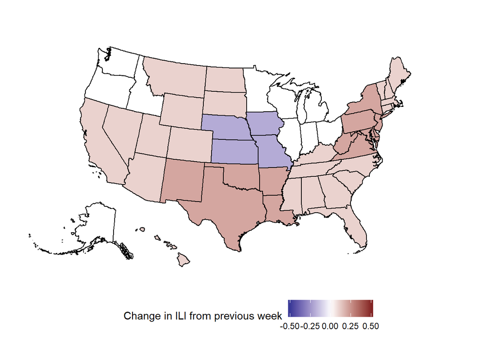

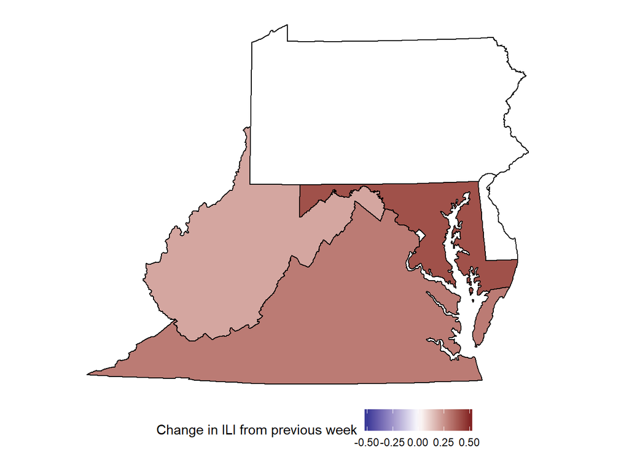

### Week 43

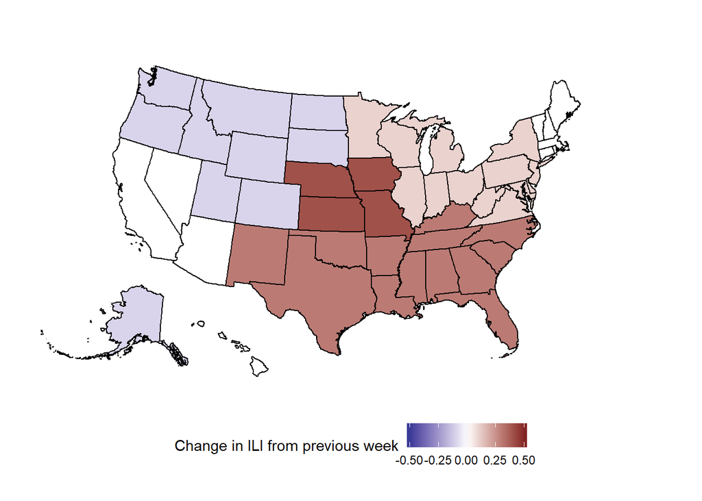

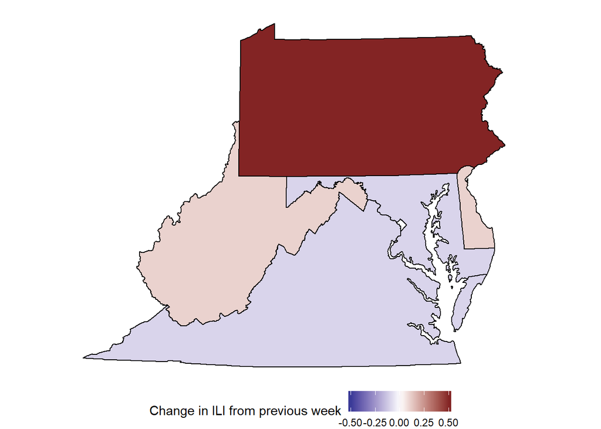

### Week 44

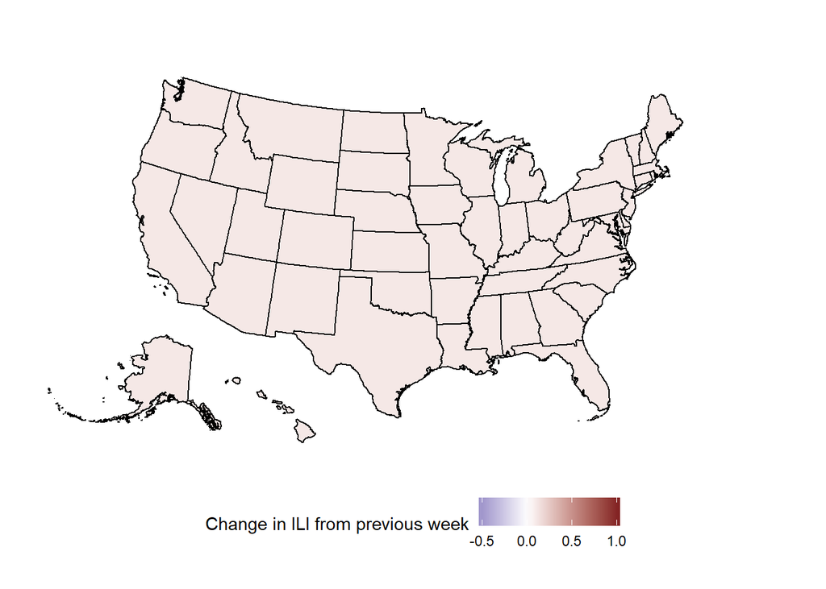

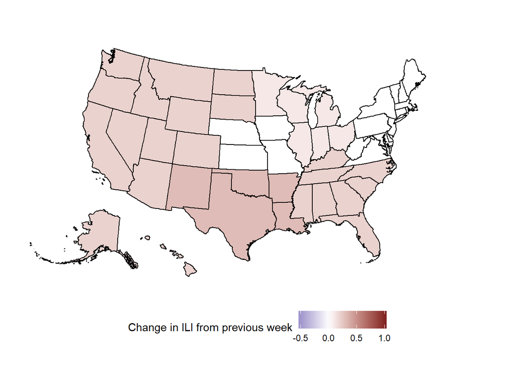

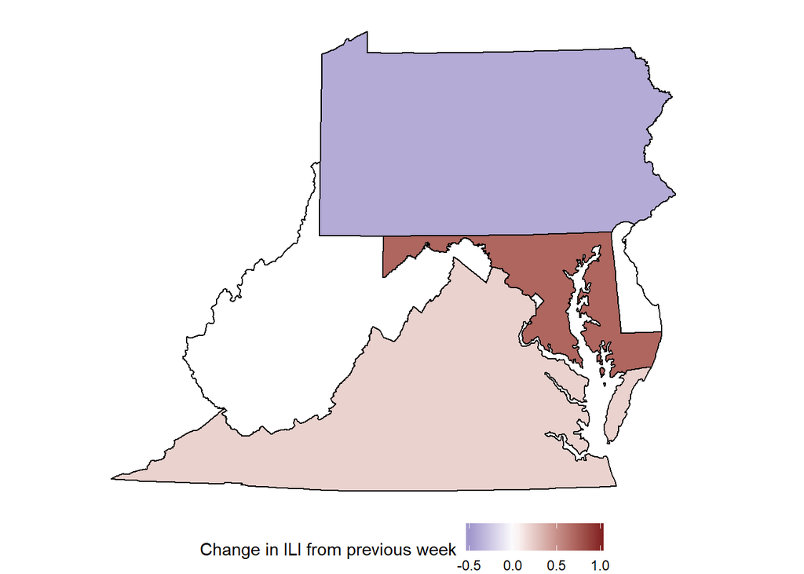

### Week 45

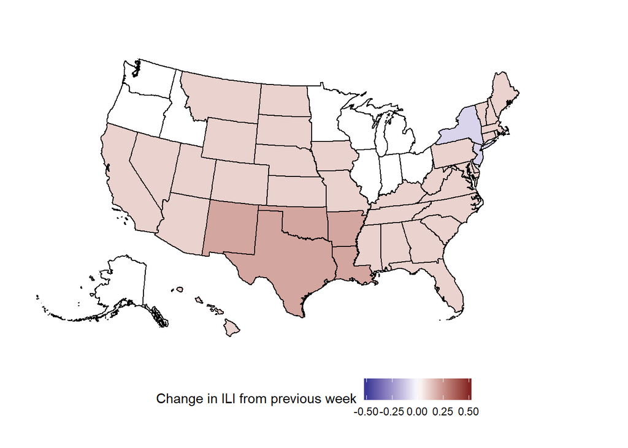

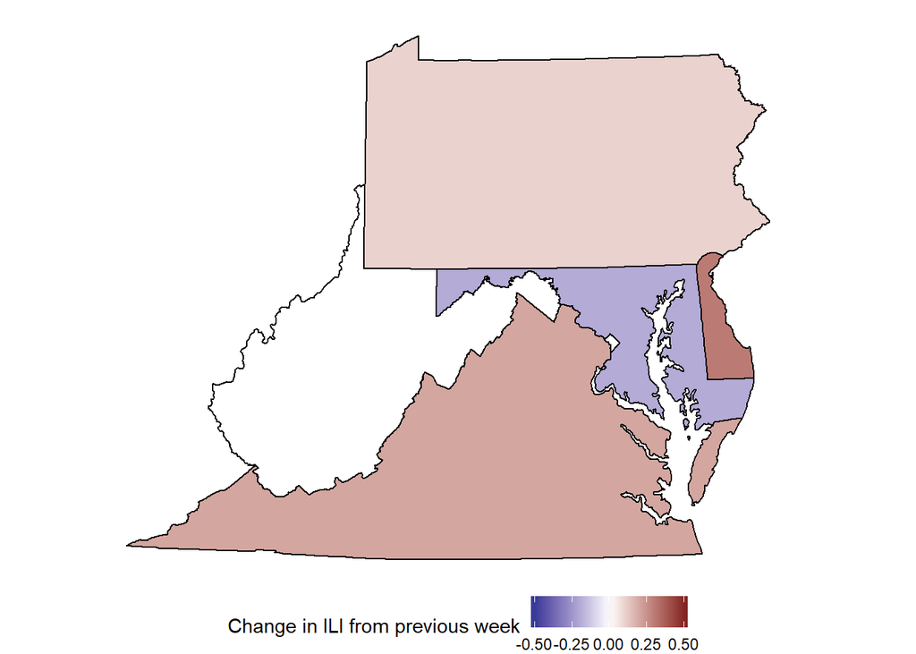

### Week 46

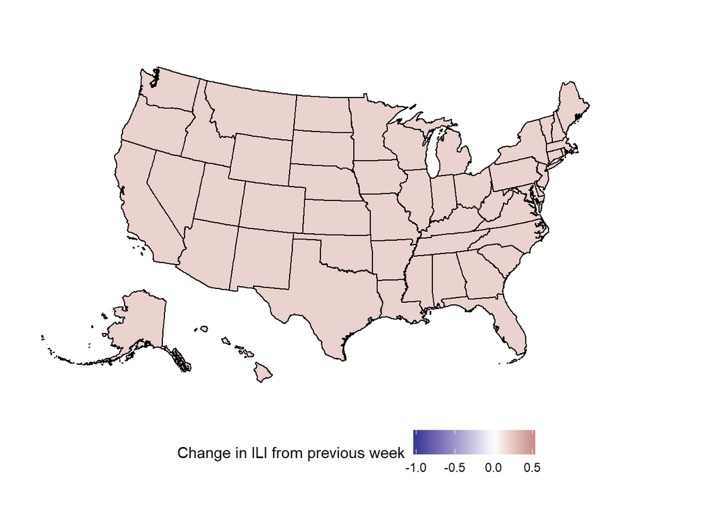

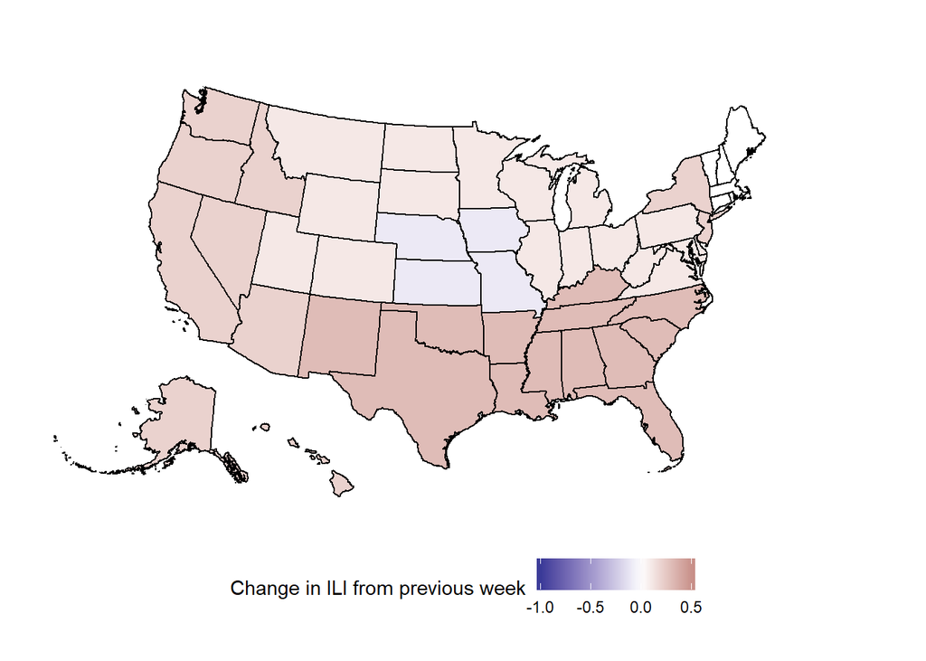

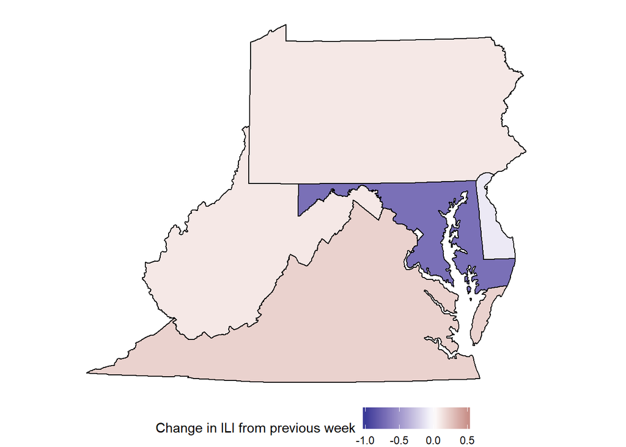

### Week 47

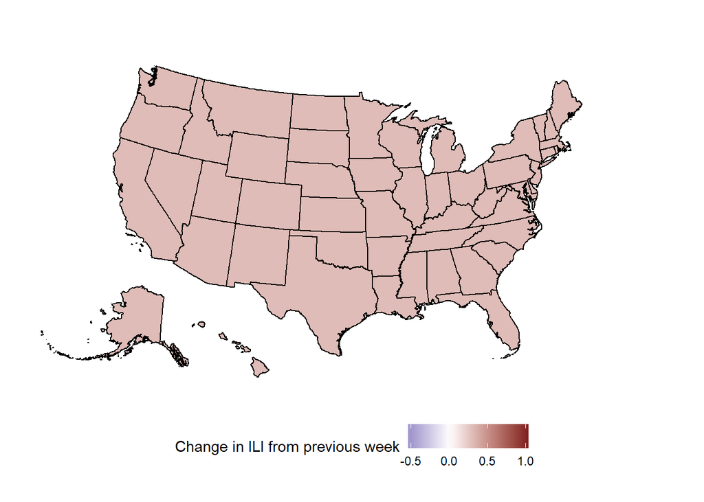

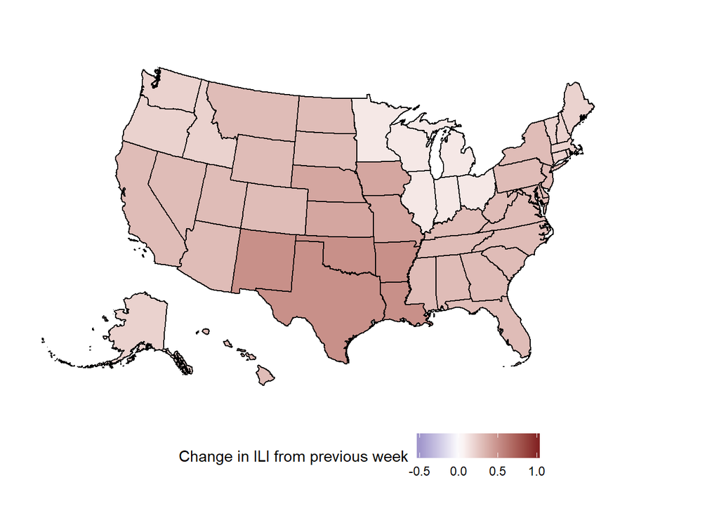

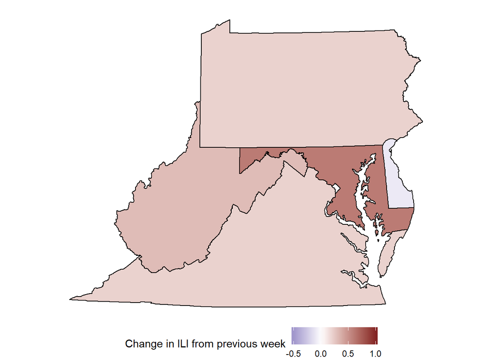

### Week 48

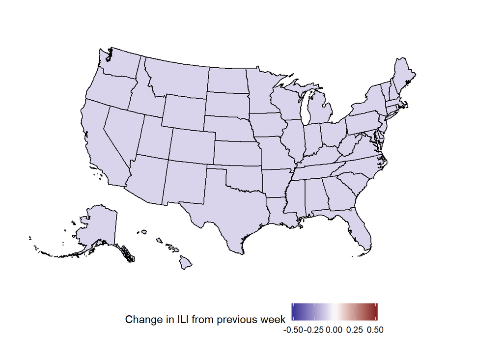

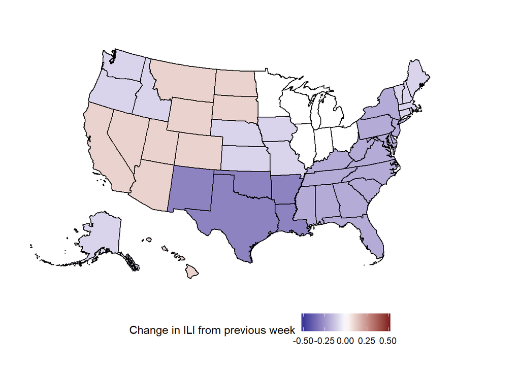

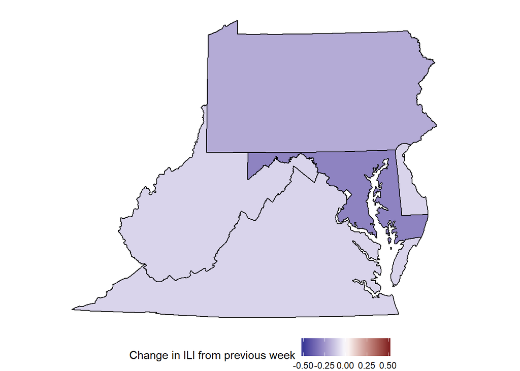

### Week 49

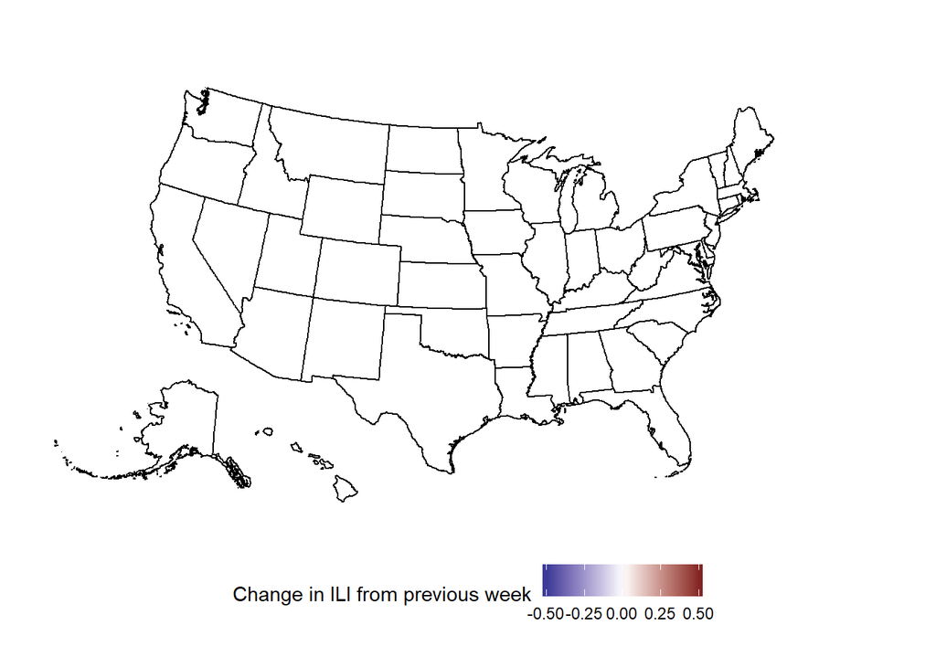

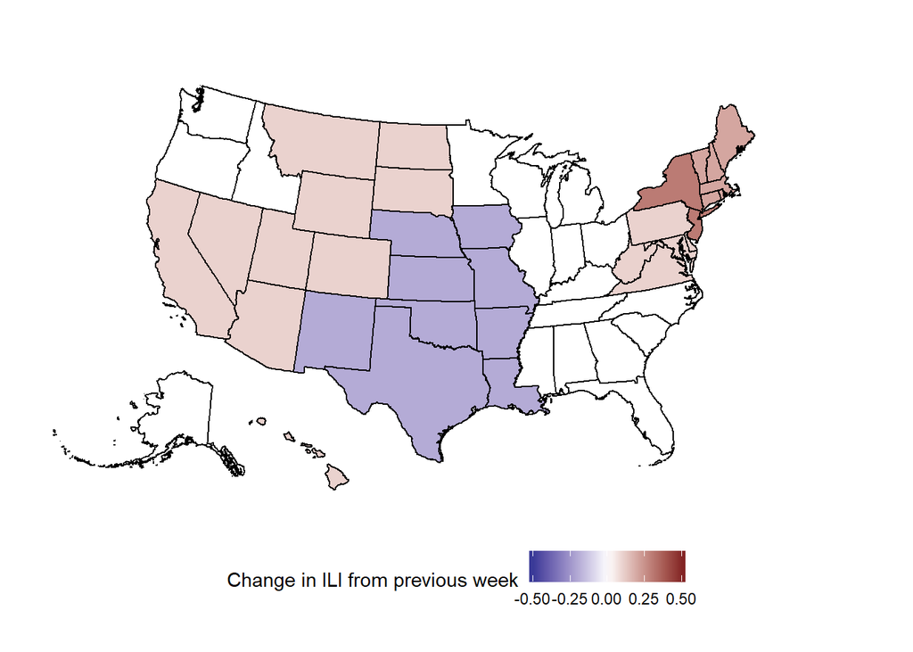

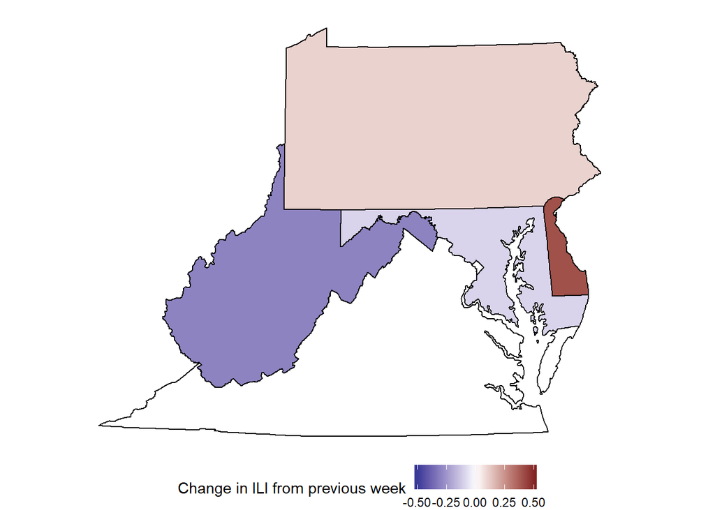